# hw3

Ian Nel

2/22/2021

# Homework 03

You will analyze data looking at the relationship between **green reputation** and three personality traits–**compassion**, **intellectual curiosity**, and **openness to experiences**. The dataset includes data from **students** and **non-students**.

```r
dictionary <- readr::read_csv(here::here("hw_3", "green_dictionary.csv"))
green_data <- readr::read_csv(here::here("hw_3", "green_data.csv"))
```

For your assignment, do the following.

1. Inspect the item responses (e.g., with graphs or by summarizing distinct values). Is anything unusual?
2. Compute total scores for the four scales. Recode variables as needed.
3. Rescale the variables so that they go from 0-100 instead of the original range. Name the recaled variables `*_pomp`.
4. Make plots that illustrate the distributions of the 4 POMP-scored variables.
5. Make scatterplots showing the relationships between **green reputation** and each personality trait. Include trend lines for **students** and **non-students**. What do these plots show?
6. Compare **green reputation** for students and non-students using a **rainfall plot** (bar + density + data points).
7. Compute a summary table of means, SDs, medians, minima, and maxima for the four total scores for students and non-students.

In your assignment, prepare an RMarkdown file that includes both the coding and (for 4-7) narrative descriptions of your results.

## 1) Inspect the item responses (e.g., with graphs or by summarizing distinct values). Is anything unusual?

```r
print(green_data)
```

```
## # A tibble: 373 x 37
##    id    green1 green2 green3 green4 green5 comp1 comp2 comp3 comp4 comp5 comp6
##    <chr>  <dbl>  <dbl>  <dbl>  <dbl>  <dbl> <dbl> <dbl> <dbl> <dbl> <dbl> <dbl>
##  1 9099       4      2      5      4      3     2     5     4     4     2     2
##  2 6275       3      5      3      3      1     4     5     4     5     5     1
##  3 8116       4      2      5      4      3     4     5     5     4     5     1
##  4 8586       4      3      5      4      3     4     5     5     4     5     1
##  5 0406       3      2      4      4      4     4     4     4     4     4     2
##  6 5645       4      3      4      4      3     5     5     5     4     4     2
##  7 3788       1      1      1      1      1     3     3     3     3     3     3
##  8 8424       4      3      2      2      2     1     1     1     2     2     4
##  9 8450       4      2      3      5      2     4     4     4     4     4     1
## 10 0512       4      2      5      5      4     5     2     5     4     2     2
## # ... with 363 more rows, and 25 more variables: comp7 <dbl>, comp8 <dbl>,
## #   comp9 <dbl>, comp10 <dbl>, intel1 <dbl>, intel2 <dbl>, intel3 <dbl>,
## #   intel4 <dbl>, intel5 <dbl>, intel6 <dbl>, intel7 <dbl>, intel8 <dbl>,
## #   intel9 <dbl>, intel10 <dbl>, open1 <dbl>, open2 <dbl>, open3 <dbl>,
## #   open4 <dbl>, open5 <dbl>, open6 <dbl>, open7 <dbl>, open8 <dbl>,
## #   open9 <dbl>, open10 <dbl>, student <dbl>
```

```r
summary(green_data) #some values are coded as -99, so I'm going to code them as
```

```
##       id                green1          green2         green3
##  Length:373         Min.   :1.000   Min.   :1.00   Min.   :1.000
##  Class :character   1st Qu.:3.000   1st Qu.:2.00   1st Qu.:3.000
##  Mode  :character   Median :4.000   Median :3.00   Median :4.000
##                     Mean   :3.476   Mean   :2.93   Mean   :3.797
##                     3rd Qu.:4.000   3rd Qu.:4.00   3rd Qu.:4.000
##                     Max.   :5.000   Max.   :5.00   Max.   :5.000
##                     NA's   :58      NA's   :58     NA's   :58
##      green4          green5          comp1             comp2
##  Min.   :1.000   Min.   :1.000   Min.   :-99.000   Min.   :-99.000
##  1st Qu.:3.000   1st Qu.:2.000   1st Qu.:  4.000   1st Qu.:  4.000
##  Median :3.000   Median :3.000   Median :  4.000   Median :  4.000
##  Mean   :3.238   Mean   :2.835   Mean   :  3.648   Mean   :  3.702
##  3rd Qu.:4.000   3rd Qu.:4.000   3rd Qu.:  4.000   3rd Qu.:  4.500
##  Max.   :5.000   Max.   :5.000   Max.   :  5.000   Max.   :  5.000
##  NA's   :58      NA's   :58      NA's   :86        NA's   :78
##      comp3           comp4             comp5             comp6
##  Min.   :1.000   Min.   :-99.000   Min.   :-99.000   Min.   :1.000
##  1st Qu.:4.000   1st Qu.:  4.000   1st Qu.:  4.000   1st Qu.:2.000
##  Median :4.000   Median :  4.000   Median :  4.000   Median :2.000
##  Mean   :4.267   Mean   :  3.691   Mean   :  3.319   Mean   :2.161
##  3rd Qu.:5.000   3rd Qu.:  4.000   3rd Qu.:  4.000   3rd Qu.:3.000
##  Max.   :5.000   Max.   :  5.000   Max.   :  5.000   Max.   :5.000
##  NA's   :77      NA's   :85        NA's   :88        NA's   :81
##      comp7            comp8             comp9             comp10
##  Min.   :-99.00   Min.   :-99.000   Min.   :-99.000   Min.   :-99.000
##  1st Qu.:  2.00   1st Qu.:  2.000   1st Qu.:  2.000   1st Qu.:  1.000
##  Median :  2.00   Median :  2.000   Median :  2.000   Median :  2.000
##  Mean   :  1.84   Mean   :  1.739   Mean   :  1.342   Mean   :  1.577
##  3rd Qu.:  3.00   3rd Qu.:  2.000   3rd Qu.:  2.000   3rd Qu.:  2.000
##  Max.   :  5.00   Max.   :  5.000   Max.   :  5.000   Max.   :  5.000
##  NA's   :86       NA's   :90        NA's   :89        NA's   :89
##      intel1           intel2            intel3            intel4
##  Min.   :-99.00   Min.   :-99.000   Min.   :-99.000   Min.   :-99.000
##  1st Qu.:  3.00   1st Qu.:  3.000   1st Qu.:  3.000   1st Qu.:  3.000
##  Median :  4.00   Median :  4.000   Median :  4.000   Median :  4.000
##  Mean   :  3.38   Mean   :  3.336   Mean   :  2.822   Mean   :  2.656
##  3rd Qu.:  4.00   3rd Qu.:  4.000   3rd Qu.:  4.000   3rd Qu.:  4.000
##  Max.   :  5.00   Max.   :  5.000   Max.   :  5.000   Max.   :  5.000
##  NA's   :78       NA's   :90        NA's   :86        NA's   :88
```

[output cut: 25 more lines]

```
##  Min.   :-99.000   Min.   :1.000   Min.   :1.000   Min.   :-99.00
##  1st Qu.:  2.000   1st Qu.:2.000   1st Qu.:2.000   1st Qu.:  2.00
##  Median :  3.000   Median :2.000   Median :2.000   Median :  2.00
##  Mean   :  2.274   Mean   :2.599   Mean   :2.568   Mean   :  2.36
##  3rd Qu.:  4.000   3rd Qu.:3.000   3rd Qu.:4.000   3rd Qu.:  4.00
##  Max.   :  5.000   Max.   :5.000   Max.   :5.000   Max.   :  5.00
##  NA's   :85        NA's   :84      NA's   :77      NA's   :90
##     student
##  Min.   :-99.000
##  1st Qu.:  1.000
##  Median :  2.000
##  Mean   :  1.309
##  3rd Qu.:  2.000
##  Max.   :  2.000
##  NA's   :95
```

```r
dat <- green_data %>%
  mutate(student = factor(student, levels = c(1, 2))) %>%
  mutate(student = recode(student, "1" = "Non-student", "2" = "Student")) %>%
  na_if("-99")

summary(dat) #now minimum values are 1 (not -99)
```

```
##       id                green1          green2         green3
##  Length:373         Min.   :1.000   Min.   :1.00   Min.   :1.000
##  Class :character   1st Qu.:3.000   1st Qu.:2.00   1st Qu.:3.000
##  Mode  :character   Median :4.000   Median :3.00   Median :4.000
##                     Mean   :3.476   Mean   :2.93   Mean   :3.797
##                     3rd Qu.:4.000   3rd Qu.:4.00   3rd Qu.:4.000
##                     Max.   :5.000   Max.   :5.00   Max.   :5.000
##                     NA's   :58      NA's   :58     NA's   :58
##      green4          green5          comp1           comp2
##  Min.   :1.000   Min.   :1.000   Min.   :1.000   Min.   :1.000
##  1st Qu.:3.000   1st Qu.:2.000   1st Qu.:4.000   1st Qu.:4.000
##  Median :3.000   Median :3.000   Median :4.000   Median :4.000
##  Mean   :3.238   Mean   :2.835   Mean   :4.007   Mean   :4.051
##  3rd Qu.:4.000   3rd Qu.:4.000   3rd Qu.:4.000   3rd Qu.:4.750
##  Max.   :5.000   Max.   :5.000   Max.   :5.000   Max.   :5.000
##  NA's   :58      NA's   :58      NA's   :87      NA's   :79
##      comp3           comp4           comp5           comp6
##  Min.   :1.000   Min.   :1.000   Min.   :1.000   Min.   :1.000
##  1st Qu.:4.000   1st Qu.:4.000   1st Qu.:4.000   1st Qu.:2.000
##  Median :4.000   Median :4.000   Median :4.000   Median :2.000
##  Mean   :4.267   Mean   :4.049   Mean   :4.042   Mean   :2.161
##  3rd Qu.:5.000   3rd Qu.:4.000   3rd Qu.:4.000   3rd Qu.:3.000
##  Max.   :5.000   Max.   :5.000   Max.   :5.000   Max.   :5.000
##  NA's   :77      NA's   :86      NA's   :90      NA's   :81
##      comp7           comp8           comp9           comp10
##  Min.   :1.000   Min.   :1.000   Min.   :1.000   Min.   :1.000
##  1st Qu.:2.000   1st Qu.:2.000   1st Qu.:2.000   1st Qu.:1.000
##  Median :2.000   Median :2.000   Median :2.000   Median :2.000
##  Mean   :2.192   Mean   :2.096   Mean   :2.053   Mean   :1.933
##  3rd Qu.:3.000   3rd Qu.:2.000   3rd Qu.:2.000   3rd Qu.:2.000
##  Max.   :5.000   Max.   :5.000   Max.   :5.000   Max.   :5.000
##  NA's   :87      NA's   :91      NA's   :91      NA's   :90
##      intel1          intel2          intel3          intel4
##  Min.   :1.000   Min.   :1.000   Min.   :1.000   Min.   :1.000
##  1st Qu.:3.000   1st Qu.:3.000   1st Qu.:3.000   1st Qu.:3.000
##  Median :4.000   Median :4.000   Median :4.000   Median :4.000
##  Mean   :3.728   Mean   :3.699   Mean   :3.537   Mean   :3.375
##  3rd Qu.:4.000   3rd Qu.:4.000   3rd Qu.:4.000   3rd Qu.:4.000
##  Max.   :5.000   Max.   :5.000   Max.   :5.000   Max.   :5.000
##  NA's   :79      NA's   :91      NA's   :88      NA's   :90
```

[output cut: 17 more lines]

```
##  Min.   :1.000   Min.   :1.00   Min.   :1.00   Min.   :1.000   Min.   :1.000
##  1st Qu.:3.000   1st Qu.:3.00   1st Qu.:3.00   1st Qu.:3.000   1st Qu.:2.000
##  Median :4.000   Median :4.00   Median :4.00   Median :4.000   Median :3.000
##  Mean   :3.749   Mean   :3.92   Mean   :3.83   Mean   :3.592   Mean   :2.983
##  3rd Qu.:4.000   3rd Qu.:5.00   3rd Qu.:4.00   3rd Qu.:4.000   3rd Qu.:4.000
##  Max.   :5.000   Max.   :5.00   Max.   :5.00   Max.   :5.000   Max.   :5.000
##  NA's   :90      NA's   :86     NA's   :90     NA's   :86      NA's   :87
##      open8           open9           open10            student
##  Min.   :1.000   Min.   :1.000   Min.   :1.00   Non-student: 91
##  1st Qu.:2.000   1st Qu.:2.000   1st Qu.:2.00   Student    :186
##  Median :2.000   Median :2.000   Median :2.00   NA's       : 96
##  Mean   :2.599   Mean   :2.568   Mean   :2.72
##  3rd Qu.:3.000   3rd Qu.:4.000   3rd Qu.:4.00
##  Max.   :5.000   Max.   :5.000   Max.   :5.00
##  NA's   :84      NA's   :77      NA's   :91
```

## 2) Compute total scores for the four scales. Recode variables as needed.

```r
#see which variables need to be recoded
view(dictionary)

#Reverse code items
reversed <- dictionary %>%
  filter(Keying == -1) %>%
  pull(Item)

datr <- dat %>%
  mutate(
    across(all_of(reversed),
           ~ 6 - .x,
           .names = "{.col}r")
  )

#Using rowwise function to create total scores for each person

datr2 <- datr %>%
  rowwise() %>%
  mutate(
   green_tot = mean(c(green1,green2r,green3,green4,green5), na.rm = FALSE),
         comp_tot = mean(c(comp1,comp2,comp3,comp4,comp5,comp6r,comp7r,comp8r,comp9r,comp10r), na.rm = FALSE),
         intel_tot = mean(c(intel1,intel2,intel3,intel4,intel5,intel6,intel7r,intel8r,intel9r,intel10r), na.rm =FALSE),
         open_tot = mean(c(open1,open2,open3,open4,open5,open6,open7r,open8r,open9r,open10r), na.rm = FALSE)
   )

summary(datr2)
```

```
##       id                green1          green2         green3
##  Length:373         Min.   :1.000   Min.   :1.00   Min.   :1.000
##  Class :character   1st Qu.:3.000   1st Qu.:2.00   1st Qu.:3.000
##  Mode  :character   Median :4.000   Median :3.00   Median :4.000
##                     Mean   :3.476   Mean   :2.93   Mean   :3.797
##                     3rd Qu.:4.000   3rd Qu.:4.00   3rd Qu.:4.000
##                     Max.   :5.000   Max.   :5.00   Max.   :5.000
##                     NA's   :58      NA's   :58     NA's   :58
##      green4          green5          comp1           comp2
##  Min.   :1.000   Min.   :1.000   Min.   :1.000   Min.   :1.000
##  1st Qu.:3.000   1st Qu.:2.000   1st Qu.:4.000   1st Qu.:4.000
##  Median :3.000   Median :3.000   Median :4.000   Median :4.000
##  Mean   :3.238   Mean   :2.835   Mean   :4.007   Mean   :4.051
##  3rd Qu.:4.000   3rd Qu.:4.000   3rd Qu.:4.000   3rd Qu.:4.750
##  Max.   :5.000   Max.   :5.000   Max.   :5.000   Max.   :5.000
##  NA's   :58      NA's   :58      NA's   :87      NA's   :79
##      comp3           comp4           comp5           comp6
##  Min.   :1.000   Min.   :1.000   Min.   :1.000   Min.   :1.000
##  1st Qu.:4.000   1st Qu.:4.000   1st Qu.:4.000   1st Qu.:2.000
##  Median :4.000   Median :4.000   Median :4.000   Median :2.000
##  Mean   :4.267   Mean   :4.049   Mean   :4.042   Mean   :2.161
##  3rd Qu.:5.000   3rd Qu.:4.000   3rd Qu.:4.000   3rd Qu.:3.000
##  Max.   :5.000   Max.   :5.000   Max.   :5.000   Max.   :5.000
##  NA's   :77      NA's   :86      NA's   :90      NA's   :81
##      comp7           comp8           comp9           comp10
##  Min.   :1.000   Min.   :1.000   Min.   :1.000   Min.   :1.000
##  1st Qu.:2.000   1st Qu.:2.000   1st Qu.:2.000   1st Qu.:1.000
##  Median :2.000   Median :2.000   Median :2.000   Median :2.000
##  Mean   :2.192   Mean   :2.096   Mean   :2.053   Mean   :1.933
##  3rd Qu.:3.000   3rd Qu.:2.000   3rd Qu.:2.000   3rd Qu.:2.000
##  Max.   :5.000   Max.   :5.000   Max.   :5.000   Max.   :5.000
##  NA's   :87      NA's   :91      NA's   :91      NA's   :90
##      intel1          intel2          intel3          intel4
##  Min.   :1.000   Min.   :1.000   Min.   :1.000   Min.   :1.000
##  1st Qu.:3.000   1st Qu.:3.000   1st Qu.:3.000   1st Qu.:3.000
##  Median :4.000   Median :4.000   Median :4.000   Median :4.000
##  Mean   :3.728   Mean   :3.699   Mean   :3.537   Mean   :3.375
##  3rd Qu.:4.000   3rd Qu.:4.000   3rd Qu.:4.000   3rd Qu.:4.000
##  Max.   :5.000   Max.   :5.000   Max.   :5.000   Max.   :5.000
##  NA's   :79      NA's   :91      NA's   :88      NA's   :90
```

[output cut: 49 more lines]

```
##  Min.   :1.000   Min.   :1.000   Min.   :1.000   Min.   :1.000   Min.   :1.00
##  1st Qu.:3.000   1st Qu.:2.000   1st Qu.:3.000   1st Qu.:2.000   1st Qu.:2.00
##  Median :4.000   Median :3.000   Median :4.000   Median :4.000   Median :4.00
##  Mean   :3.473   Mean   :3.017   Mean   :3.401   Mean   :3.432   Mean   :3.28
##  3rd Qu.:4.000   3rd Qu.:4.000   3rd Qu.:4.000   3rd Qu.:4.000   3rd Qu.:4.00
##  Max.   :5.000   Max.   :5.000   Max.   :5.000   Max.   :5.000   Max.   :5.00
##  NA's   :92      NA's   :87      NA's   :84      NA's   :77      NA's   :91
##    green_tot        comp_tot       intel_tot        open_tot
##  Min.   :1.400   Min.   :1.900   Min.   :2.000   Min.   :1.800
##  1st Qu.:2.800   1st Qu.:3.700   1st Qu.:3.200   1st Qu.:3.200
##  Median :3.200   Median :4.000   Median :3.600   Median :3.600
##  Mean   :3.283   Mean   :4.004   Mean   :3.546   Mean   :3.624
##  3rd Qu.:3.800   3rd Qu.:4.400   3rd Qu.:4.000   3rd Qu.:4.000
##  Max.   :5.000   Max.   :5.000   Max.   :4.900   Max.   :4.800
##  NA's   :58      NA's   :94      NA's   :97      NA's   :96
```

## 3) Rescale the variables so that they go from 0-100 instead of the original range. Name the recaled variables `*_pomp`.

```r
#Using rowwise function to rescale scores for each person from a 1-5 to a 0-100 scale.
datr3 <- datr2 %>%
  rowwise() %>%
  mutate(green_pomp = rescale(green_tot, to = c(0, 100), from = c(1,5)),
         comp_pomp = rescale(comp_tot, to = c(0, 100), from = c(1,5)),
         intel_pomp = rescale(intel_tot, to = c(0, 100), from = c(1,5)),
         open_pomp = rescale(open_tot, to = c(0, 100), from = c(1,5))
  )
```

## 4) Make plots that illustrate the distributions of the 4 POMP-scored variables.

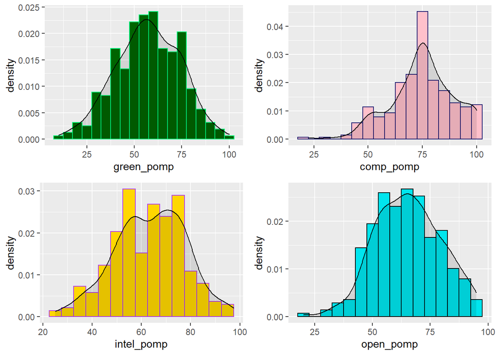

```r
green_hist <- ggplot(datr3) +
  aes(x = green_pomp, y = ..density..) +
  geom_histogram(color="springgreen",fill="dark green", binwidth = 5)+
  geom_density(alpha = .1, fill = "black")

comp_hist <- ggplot(datr3) +
  aes(x = comp_pomp, y = ..density..) +
  geom_histogram(color = "midnightblue", fill="pink", binwidth = 5)+
  geom_density(alpha = .1, fill = "black")

intel_hist <- ggplot(datr3) +
  aes(x = intel_pomp, y = ..density..) +
  geom_histogram(color = "darkorchid2", fill="gold", binwidth = 5) +
  geom_density(alpha = .1, fill = "black")

open_hist <- ggplot(datr3) +
  aes(x = open_pomp, y = ..density..) +
  geom_histogram(color="black", fill="turquoise2", binwidth = 5) +
  geom_density(alpha = .1, fill = "black")

gridExtra::grid.arrange(green_hist,comp_hist,intel_hist,open_hist)
```

### Narrative Description These histograms demonstrate that these variables have a relatively normal distribution, except for “comp_pomp” which is skewed to the left. “Intel_pomp” also appears to be somewhat bimodal.

## 5) Make scatterplots showing the relationships between **green reputation** and each personality trait. Include trend lines for **students** and **non-students**. What do these plots show?

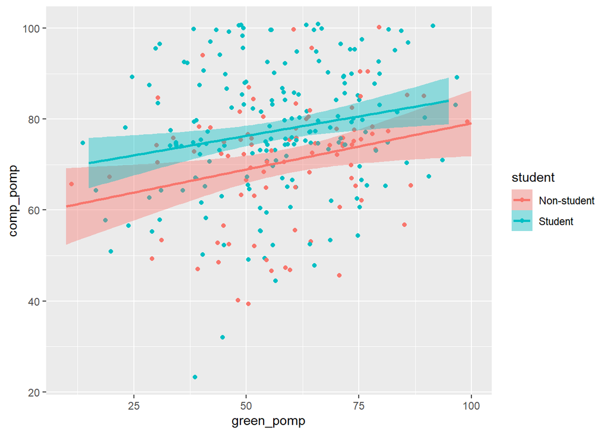

```r
datr3 %>%
  filter(!is.na(student)) %>%
  ggplot() +
  aes(y = comp_pomp,
      x = green_pomp,
      group = student,
      color = student,
      fill = student) +
  geom_jitter() +
  geom_smooth(method = "lm")
```

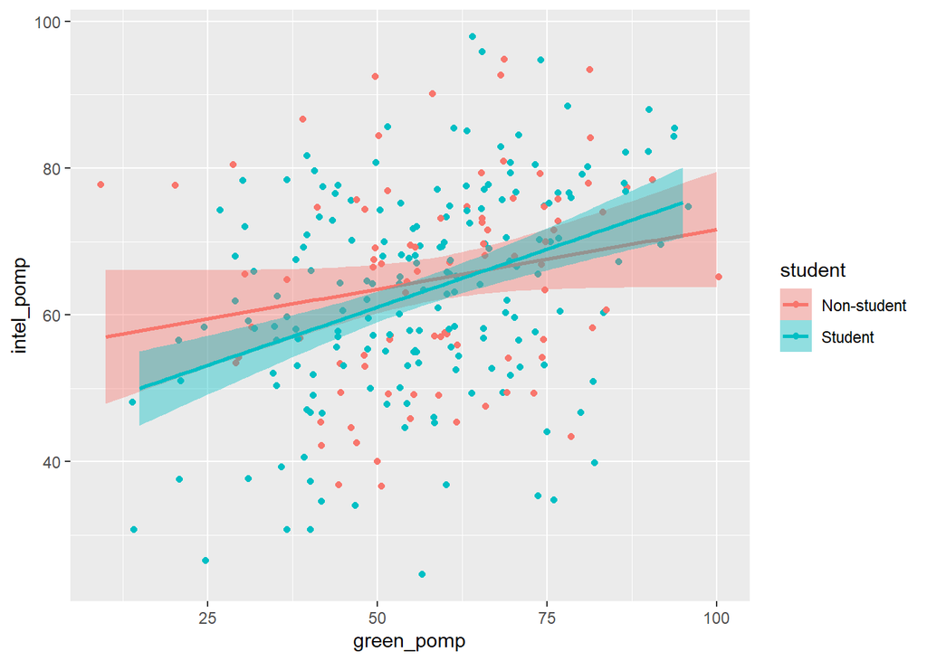

```r
datr3 %>%
  filter(!is.na(student)) %>%
  ggplot() +
  aes(y = intel_pomp,
      x = green_pomp,
      group = student,
      color = student,
      fill = student) +
  geom_jitter() +
  geom_smooth(method = "lm")
```

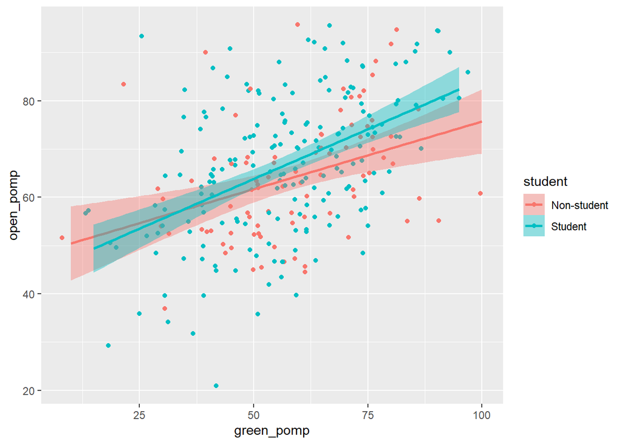

```r
datr3 %>%
  filter(!is.na(student)) %>%
  ggplot() +
  aes(y = open_pomp,
      x = green_pomp,
      group = student,
      color = student,
      fill = student) +
  geom_jitter() +
  geom_smooth(method = "lm")
```

## 6) Compare **green reputation** for students and non-students using a **rainfall plot** (bar + density + data points).

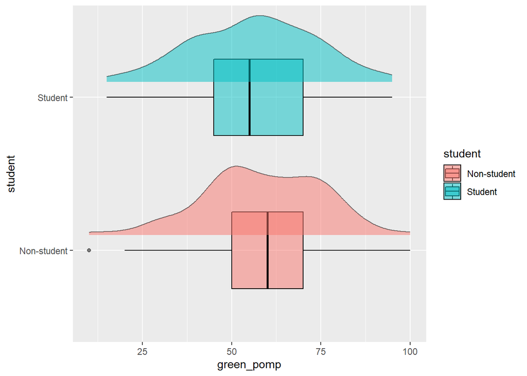

```r
datr3 %>%
  filter(!is.na(student)) %>%
ggplot() +
  aes(y = student,
      x = green_pomp,
      fill = student,
      color = student) +
  geom_boxplot(color = "black",
               alpha = .5,
               width = .5,
               size = .5) +
  ggdist::stat_slab(height = .5,
                    color = "black",
                    size = .5,
                    alpha = .5,
                    position = position_nudge(y = .1))
```

### Narrative Description This rainfall plot shows that the median green_pomp for non-students is slightly larger for non-students than for students. The green_pomp distribution for non-students appears to be more bimodal, whereas the distribution for students appears to be normal.

## 7) Compute a summary table of means, SDs, medians, minima, and maxima for the four total scores for students and non-students.

```r
sumtable <- datr3 %>%
  na.omit() %>%
  group_by(student) %>%
  summarize(across(c(green_pomp,open_pomp,intel_pomp,comp_pomp),
                   list(Mean = ~ mean(.x, na.rm = TRUE),
                        SD = ~ sd(.x, na.rm = TRUE),
                        Median = ~ median(.x, na.rm = TRUE),
                        Min = ~ min(.x, na.rm = TRUE),
                        Max = ~ max(.x, na.rm = TRUE)))
  )
kable(sumtable)
```

| student | green_pomp_Mean | green_pomp_SD | green_pomp_Median | green_pomp_Min | green_pomp_Max | open_pomp_Mean | open_pomp_SD | open_pomp_Median | open_pomp_Min | open_pomp_Max | intel_pomp_Mean | intel_pomp_SD | intel_pomp_Median | intel_pomp_Min | intel_pomp_Max | comp_pomp_Mean | comp_pomp_SD | comp_pomp_Median | comp_pomp_Min | comp_pomp_Max |
| --- | --- | --- | --- | --- | --- | --- | --- | --- | --- | --- | --- | --- | --- | --- | --- | --- | --- | --- | --- | --- |
| Non-student | 58.35294 | 16.73299 | 60 | 10 | 100 | 64.05882 | 12.64191 | 62.5 | 37.5 | 95 | 65.00000 | 13.97276 | 67.5 | 37.5 | 95.0 | 70.91176 | 13.33992 | 75.0 | 40.0 | 100 |
| Student | 56.62921 | 17.14470 | 55 | 15 | 95 | 66.74157 | 14.93349 | 67.5 | 20.0 | 95 | 63.03371 | 14.41648 | 65.0 | 25.0 | 97.5 | 77.80899 | 14.22588 | 77.5 | 22.5 | 100 |

Non-students had a greater mean and median green reputation and intellectual curiosity compared with students, whereas students had a higher mean and median openness to experience and compassion.